# Reproduceable Research - Week 2 Assignment

Nils

25 September 2016

# Submission Week 2 - Making research reproducable

## Commit containing full submission

1. Code for reading in the dataset and/or processing the data
2. Histogram of the total number of steps taken each day
3. Mean and median number of steps taken each day
4. Time series plot of the average number of steps taken
5. The 5-minute interval that, on average, contains the maximum number of steps
6. Code to describe and show a strategy for imputing missing data
7. Histogram of the total number of steps taken each day after missing values are imputed
8. Panel plot comparing the average number of steps taken per 5-minute interval across weekdays and weekends
9. All of the R code needed to reproduce the results (numbers, plots, etc.) in the report

## 1. Read from the file.

The working dorectory is already set. Therefore the file can be read with the following code:

```r
setwd("C:/Users/nilsn/Google Drive/Weiterbildung/R Programming/reproducablaresearch/week 2")
input <- read.csv("activity.csv")
input <- as.data.frame(input)
input$date <- as.Date(as.character(input$date), "%Y-%m-%d")
input$steps <- as.numeric(input$steps)
input$interval <- as.numeric(input$interval)
```

Additionally the table is formatted as a data frame and the date column is formated as date.

## 2. Histogram of the total number of steps taken each day

```r
summary(input$date)
```

```
##         Min.      1st Qu.       Median         Mean      3rd Qu.
## "2012-10-01" "2012-10-16" "2012-10-31" "2012-10-31" "2012-11-15"
##         Max.
## "2012-11-30"
```

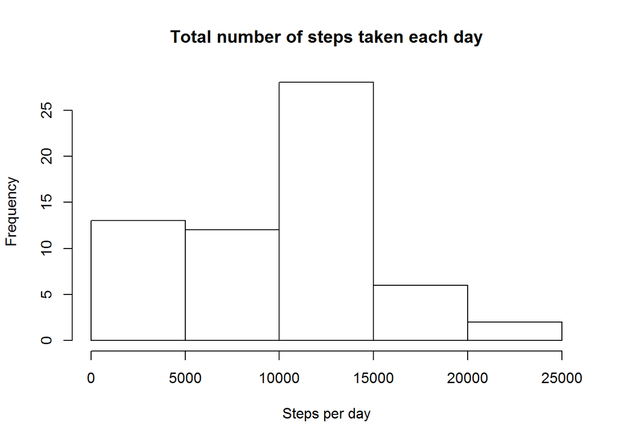

```r
no1 <- aggregate(input$steps,by = list(date=input$date), FUN = sum, na.rm = TRUE)
hist(no1$x, xlab = "Steps per day", main = "Total number of steps taken each day")
```

## 3. Mean and median number of steps taken each day

The next figure shows the mean & median of steps each day, if NA values are interpreted as 0 steps.

```r
mean(no1$x)
```

```
## [1] 9354.23
```

```r
median(no1$x)
```

```
## [1] 10395
```

## 4. Time series plot of the average number of steps taken

The first step is to aggreagte the data on mean per day, the next step is to plot the data.

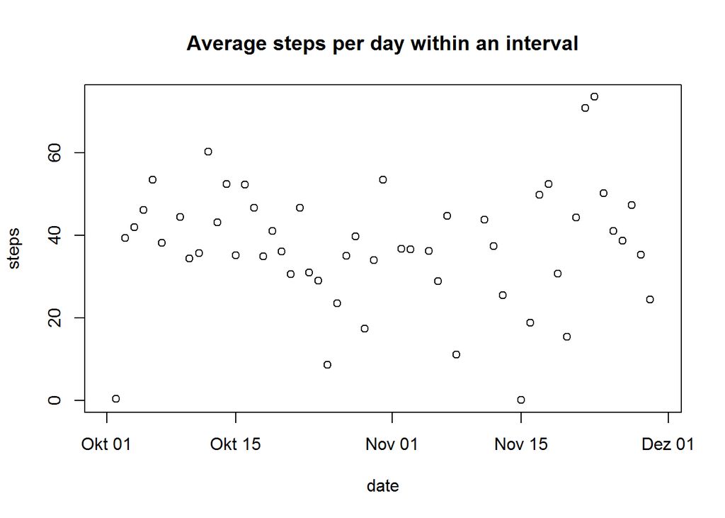

```r
no4 <- aggregate(input$steps,by = list(date=input$date), FUN = mean, na.rm = TRUE)
plot(no4$date, no4$x, xlab = "date", ylab = "steps", main = "Average steps per day within an interval")
```

## 5. The 5-minute interval that, on average, contains the maximum number of steps

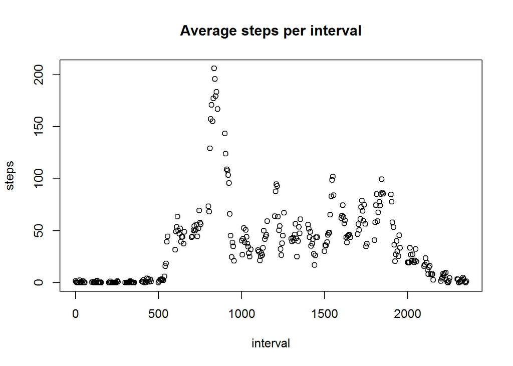

```r
no5 <- aggregate(input$steps,by = list(interval=input$interval), FUN = mean, na.rm = TRUE)
plot(no5$interval, no5$x, xlab = "interval", ylab = "steps", main = "Average steps per interval")
```

```r
library(dplyr)
filter(no5, x == max(x))
```

```
##   interval        x
## 1      835 206.1698
```

## 6. Code to describe and show a strategy for imputing missing data

Instead of using the claasical imputation code of impute, this data set uses the mice package to impute the missing values.

For this reason in a first step, all variables need to be converted to numeric vectors. Afterwards the relevant items are imputed.

```r
input2 <- input
input2$date <- as.numeric(input2$date)
library(mice)
full <- mice(input2, m=3, maxit = 50, meth = "pmm", seed = 500)
completedData <- complete(full,1)
```

## 7. Histogram of the total number of steps taken each day after missing values are imputed

The completed data set is added as new columns to the input data. From this the histogram is done, similiar to task 2.

```r
summary(completedData$date)
```

```
##    Min. 1st Qu.  Median    Mean 3rd Qu.    Max.
##   15610   15630   15640   15640   15660   15670
```

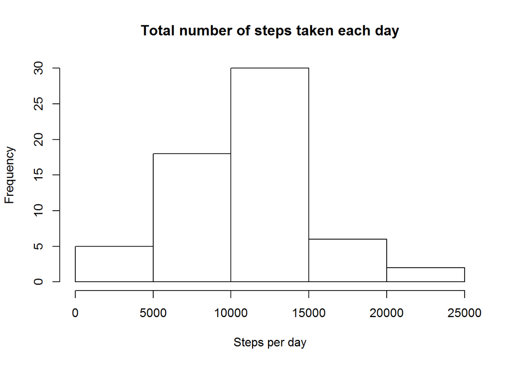

```r
input$steps2 <- completedData$steps
rm(input2, completedData)
no7 <- aggregate(input$steps2,by = list(date=input$date), FUN = sum, na.rm = TRUE)
hist(no7$x, xlab = "Steps per day", main = "Total number of steps taken each day")
```

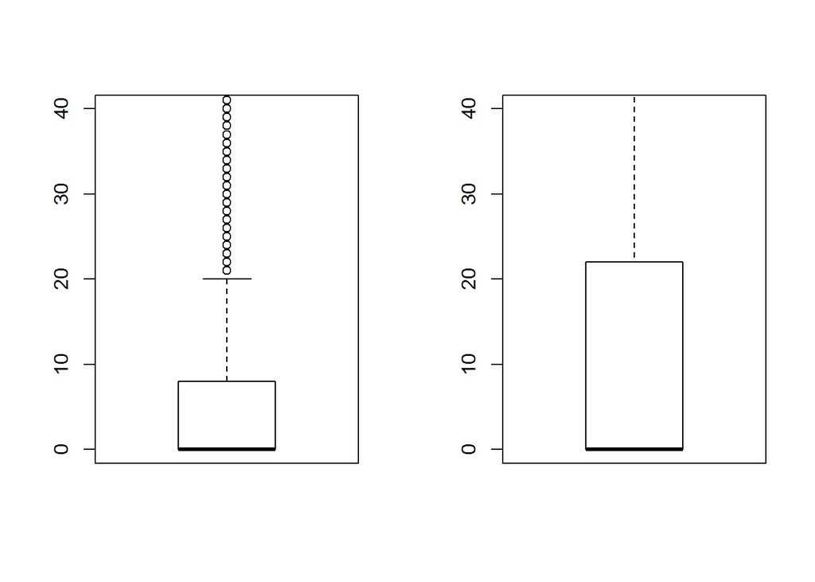

```r
input$weekday <- weekdays(input$date)
weedays <- unique(input$weekday)[1:5]
weekends <- unique(input$weekday)[6:7]
aveweekend <- input[which(input$weekday=="Samstag" |input$weekday=="Sonntag"),]
avewd <- mean(aveweekend$steps2)
aveweekday <- input[which(!input$weekday=="Samstag" & !input$weekday=="Sonntag"),]
avewy <- mean(aveweekday$steps2)
par(mfrow = c(1, 2))
boxplot(aveweekday$steps2, ylim = c(0,40))
boxplot(aveweekend$steps2, ylim = c(0,40))
```

```r
input <- as.data.frame(input)
input$date <- as.Date(as.character(input$date), "%Y-%m-%d")
input$steps <- as.numeric(input$steps)
input$interval <- as.numeric(input$interval)
summary(input$date)
no1 <- aggregate(input$steps,by = list(date=input$date), FUN = sum, na.rm = TRUE)
hist(no1$x, xlab = "Steps per day", main = "Total number of steps taken each day")
mean(no1$x)
median(no1$x)
no4 <- aggregate(input$steps,by = list(date=input$date), FUN = mean, na.rm = TRUE)
plot(no4$date, no4$x, xlab = "date", ylab = "steps", main = "Average steps per day within an interval")
no5 <- aggregate(input$steps,by = list(interval=input$interval), FUN = mean, na.rm = TRUE)
plot(no5$interval, no5$x, xlab = "interval", ylab = "steps", main = "Average steps per interval")
library(dplyr)
filter(no5, x == max(x))
input2 <- input
input2$date <- as.numeric(input2$date)
library(mice)
full <- mice(input2, m=3, maxit = 50, meth = "pmm", seed = 500)
completedData <- complete(full,1)
summary(completedData$date)
input$steps2 <- completedData$steps
rm(input2, completedData)
no7 <- aggregate(input$steps2,by = list(date=input$date), FUN = sum, na.rm = TRUE)
hist(no7$x, xlab = "Steps per day", main = "Total number of steps taken each day")
input$weekday <- weekdays(input$date)
weedays <- unique(input$weekday)[1:5]
weekends <- unique(input$weekday)[6:7]
aveweekend <- input[which(input$weekday=="Samstag" |input$weekday=="Sonntag"),]
avewd <- mean(aveweekend$steps2)
aveweekday <- input[which(!input$weekday=="Samstag" & !input$weekday=="Sonntag"),]
avewy <- mean(aveweekday$steps2)
par(mfrow = c(1, 2))
boxplot(aveweekday$steps2, ylim = c(0,40))
boxplot(aveweekend$steps2, ylim = c(0,40))
```